# BOMP research meeting

Luyi Wang

2023-09-14

# Introduction

Senft RA, Diaz-Rohrer B, Colarusso P, Swift L, Jamali N, et al. (2023) A biologist’s guide to planning and performing quantitative bioimaging experiments. *PLOS Biology* 21(6): e3002167. https://doi.org/10.1371/journal.pbio.3002167

# Example 1: Superplot

As them main paper suggested, a superplot provides not only summary statistics (e.g. mean) but also data distribution which includes individual data points.

The data and code from this exercise is from the paper below:

Samuel J. Lord, Katrina B. Velle, R. Dyche Mullins, Lillian K. Fritz-Laylin; SuperPlots: Communicating reproducibility and variability in cell biology. *J Cell Biol* 1 June 2020; 219 (6): e202001064. https://doi.org/10.1083/jcb.202001064

### Load libraries

```r
library(dplyr)
library(ggplot2)
library(ggbeeswarm)
library(ggpubr)
library(pwr)
library(data.table)
library(ggforce)
library(car)
library(multcomp)
library(stringr)
```

### Import data

```r
dat <- read.table(file = "../dat/superplot data.txt",  # path to the file
           header = T,    # Whether to display the header
           sep = ",")     # Separator
head(dat)
```

```
##   Replicate Treatment    Speed
## 1         1   Control 43.69202
## 2         1   Control 41.85664
## 3         1   Control 49.11707
## 4         1   Control 49.79331
## 5         1   Control 41.54301
## 6         1   Control 44.04201
```

### Data wrangling

```r
ReplicateAverages <- dat %>%
  group_by(Treatment, Replicate) %>%
  summarise_each(list(mean))
head(ReplicateAverages)
```

```
## # A tibble: 6 × 3
## # Groups:   Treatment [2]
##   Treatment Replicate Speed
##   <chr>         <int> <dbl>
## 1 Control           1  41.5
## 2 Control           2  32.6
## 3 Control           3  20.6
## 4 Drug              1  29.6
## 5 Drug              2  22.3
## 6 Drug              3  12.9
```

### Plot data

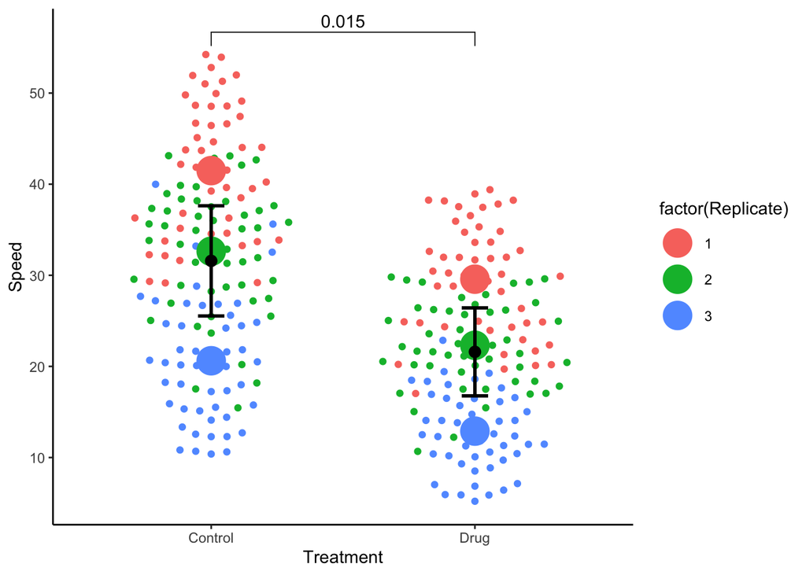

```r
ggplot(dat,
       aes(x = Treatment, y = Speed, color = factor(Replicate))) +
  geom_beeswarm(cex = 3) + # spread the individual data points
  geom_beeswarm(data = ReplicateAverages, size = 8) +
  stat_compare_means(data = ReplicateAverages,
                     comparisons = list(c("Control", "Drug")),
                     method = "t.test", # add p value on the figure
                     paired = TRUE) +
  stat_summary(fun = "mean", geom = "point", colour = "black", size = 3, data = ReplicateAverages)  +
  stat_summary(fun.data = "mean_se", geom = "errorbar", width = .1, colour = "black", size = 1, data = ReplicateAverages) +
  theme_classic()
```

# Example 2: Power analysis

In the main paper, it also mentions about running power analysis to estimate the required sample number.

Here is an example derived from the webpage: https://www.alexanderdemos.org/ANOVA4.html#Cohen’s_(d)

To run a power analysis for sample size estimation, you will need:

1. Effect size (in Cohen’s d): based on literature
2. significance level: 0.05
3. power: 0.8

In the the function pwr.t.test, you put NULL for the parameter you aim to estimate.

```r
power.analysis <- pwr.t.test(n = NULL,
                             d = 0.4,
                             sig.level = 0.05,
                             power = 0.80,
                             type = c("two.sample"),
                             alternative = c("two.sided"))
power.analysis
```

```
##
##      Two-sample t test power calculation
##
##               n = 99.08032
##               d = 0.4
##       sig.level = 0.05
##           power = 0.8
##     alternative = two.sided
##
## NOTE: n is number in *each* group
```

# Example 3: Statistical analysis and data visualisation in R

Here is an example statistical analysis replicate the analysis run in GraphPad Prism 8 in the following paper:

Li, J., Shami, G.J., Cho, E. et al. Repurposing the mitotic machinery to drive cellular elongation and chromatin reorganisation in Plasmodium falciparum gametocytes. *Nat Commun* 13, 5054 (2022). https://doi.org/10.1038/s41467-022-32579-4

I am trying to replicate the statistical analysis and figure from the paper:

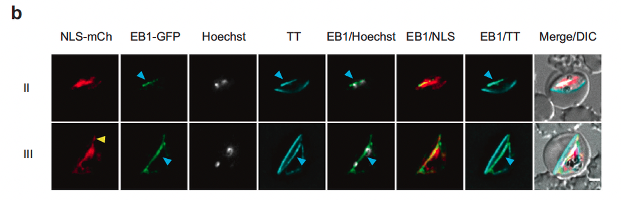

End-binding protein-1, EB1, has been used as a marker of mitotic microtubules in *Toxoplasma gondii*.

### Import data and data wrangling

```r
length.dat.raw <- read.csv("../dat/figure2c data.csv", header = F)

temp.lengthdat1 <- length.dat.raw[3:5, 1:21] %>%
  transpose()  %>% janitor::row_to_names(1) %>%
  tidyr::gather(key = "stage", value = "length") %>%
  mutate(treatment = "EB1")

temp.lengthdat2 <- length.dat.raw[8:10, 1:21] %>%
  transpose()  %>% janitor::row_to_names(1) %>%
  tidyr::gather(key = "stage", value = "length") %>%
  mutate(treatment = "MT")

length.dat <- bind_rows(temp.lengthdat1, temp.lengthdat2) %>%
  mutate(across('stage', str_replace, 'III', 'IIIa'))


#assign data class
length.dat$length <- as.numeric(length.dat$length)
length.dat$stage = as.factor(length.dat$stage)
length.dat$treatment = as.factor(length.dat$treatment)
```

### Plot the data

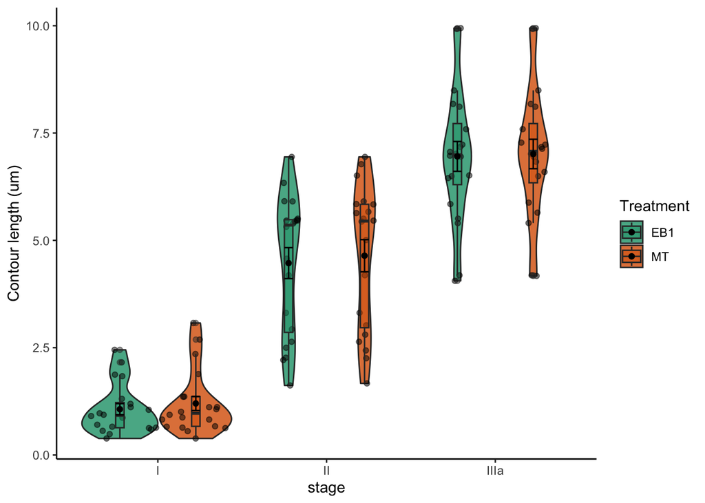

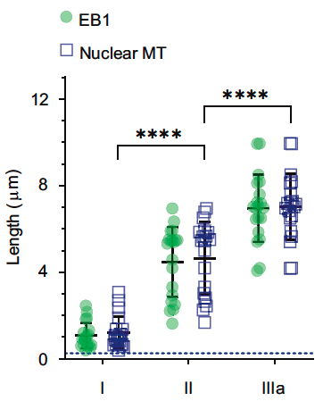

```r
ggplot(length.dat,
       aes(x = stage, y = length, category = treatment, fill = treatment)) +
  geom_violin(alpha = 0.8) +
  geom_sina(alpha = 0.5) +
  scale_fill_brewer(palette = "Dark2", name = "Treatment") +
  geom_boxplot(width = .1,
               alpha = 0.5,
               position = position_dodge(.9))+
  stat_summary(fun = "mean", geom = "point",
               position = position_dodge(.9))  +
  stat_summary(fun.data = "mean_se", geom = "errorbar", width = .1,
               position = position_dodge(.9)) +
  ylab("Contour length (um)") +
  theme_classic()
```

### Statistical analysis

#### Data overview

```r
table(length.dat$stage, length.dat$treatment)
```

```
##
##        EB1 MT
##   I     20 20
##   II    20 20
##   IIIa  20 20
```

#### Normality test

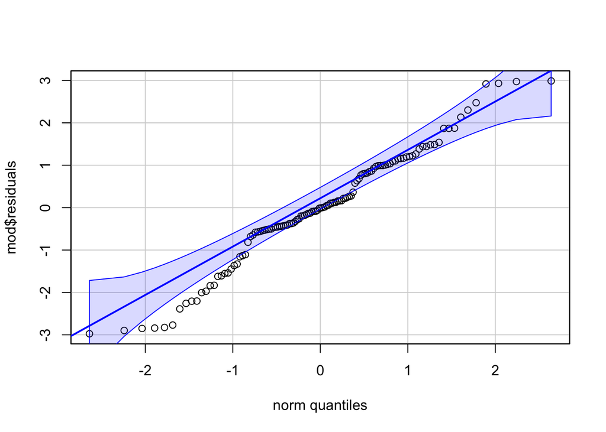

```r
# Check normality using QQ plot
mod <- aov(length ~ stage * treatment,
  data = length.dat)
qqPlot(mod$residuals, id = F)
```

```r
shapiro.test(mod$residuals)
```

```
##
##  Shapiro-Wilk normality test
##
## data:  mod$residuals
## W = 0.97746, p-value = 0.04136
```

#### Two-way ANOVA

```r
summary(mod)
```

```
##                  Df Sum Sq Mean Sq F value Pr(>F)
## stage             2  691.0   345.5 187.221 <2e-16 ***
## treatment         1    0.4     0.4   0.239  0.626
## stage:treatment   2    0.1     0.0   0.019  0.981
## Residuals       114  210.4     1.8
## ---
## Signif. codes:  0 '***' 0.001 '**' 0.01 '*' 0.05 '.' 0.1 ' ' 1
```

Tukey post-hoc

```r
res_tukey <- glht(mod, linfct = mcp(stage = "Tukey"))
summary(res_tukey)
```

```
##
##   Simultaneous Tests for General Linear Hypotheses
##
## Multiple Comparisons of Means: Tukey Contrasts
##
##
## Fit: aov(formula = length ~ stage * treatment, data = length.dat)
##
## Linear Hypotheses:
##                Estimate Std. Error t value Pr(>|t|)
## II - I == 0      3.4031     0.4296   7.922   <1e-06 ***
## IIIa - I == 0    5.8888     0.4296  13.708   <1e-06 ***
## IIIa - II == 0   2.4857     0.4296   5.786   <1e-06 ***
## ---
## Signif. codes:  0 '***' 0.001 '**' 0.01 '*' 0.05 '.' 0.1 ' ' 1
## (Adjusted p values reported -- single-step method)
```